# R Notebook

Name: Mayuri Patel

Email: mpate131@uncc.edu

title: “Lab1 AdvStats”

Consider a “loaded” die that has a 10% chance of getting a 1-5 and a 50% chance of getting a 6. (This is from the dishonest casino in the Durbin et al. book; this example is used to define algorithms for Hidden Markov Models in the first few chapters of that text book. We will see a lot more of this die in future labs and lectures).

1. What is the mean and variance for the loaded dice?
2. Make a function in R that “rolls” this dice; return a vector containing the rolls. So if I call: myRolls <- rollLoadedDie(10000) I would get a vector of size 10,000 that contains the rolls of my loaded die.
3. Make a histogram of some large number of rolls. Do the rolls of the loaded die approximate a uniform distribution?
4. Modify the code on Slide #58 of lecture #2 so that the means vs. trial size plots are from the loaded die. Generate these plots a few times. How many rolls appear to be necessary to get convergence on the expected values for the mean and variance?
- The loaded die probabilities for 1-5 numbers are 1/10 (0.1) and for number 6 is 1/2 (0.5).
1. The mean and variance for the loaded die are:

```r
#The mean for loaded die:
#Here, we add the probability of each die by multiplying it with die number to generate the mean value.
loaded_mean <- 0.1*1+0.1*2+0.1*3+0.1*4+0.1*5+0.5*6
loaded_mean
```

```
[1] 4.5
```

```r
#The variance for loaded die:
#Here, we are calculating the variance using calculated mean value.
#Variance is mean squared deviation of the observation from the mean.
loaded_variance <- 0.1*(1-4.5)^2+0.1*(2-4.5)^2+0.1*(3-4.5)^2+0.1*(4-4.5)^2+0.1*(5-4.5)^2+0.5*(6-4.5)^2
loaded_variance
```

```
[1] 3.25
```

2. Make a function to Return a vector containing the rolls for loaded die :

```r
#The probabilities for loaded die are concatenated..
loaded_prob <- c(0.1,0.1,0.1,0.1,0.1,0.5)
loaded_prob
```

```
[1] 0.1 0.1 0.1 0.1 0.1 0.5
```

```r
#A function is written which takes in number of rolls and return the rolls for loaded die.
rollLoadedDie <- function(numrolls){

    #we are making a vector that takes in length of number of rolls..
    rolls <- vector(length=numrolls,mode ="double")
    #for loop the number of rolls to sample the die from 1-6 with its probabilities
    for (i in 1:numrolls) rolls[i] <-sample(1:6,size=1,replace=TRUE,prob=loaded_prob)
    #Here, we are calculating mean and variance to verify if it is same as we did before using formula
    print(paste("The Mean value is:",mean(rolls)))
    print(paste("The Variance value is:",var(rolls)))

    #It returns the rolls
    return(rolls)

}

#calling the function which takes in number of rolls and returning the rolls...
#I just return the rolls instead of printing the values as it is a huge number.
myRolls <- rollLoadedDie(10000)
```

```
[1] "The Mean value is: 4.4973"
[1] "The Variance value is: 3.25051776177618"
```

3. Histogram of some large number of rolls:
- I am using some of large numbers from myRolls as it is 10,000 rolls large. As the histogram is for loaded die the probabilities are already counted in the above function for myRolls.

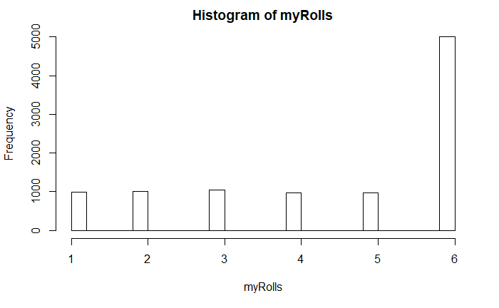

```r
hist(myRolls,10000,breaks=20)
```

- I have plotted another histogram that generates same output as above using sample() function that takes in integer numbers and size of it.

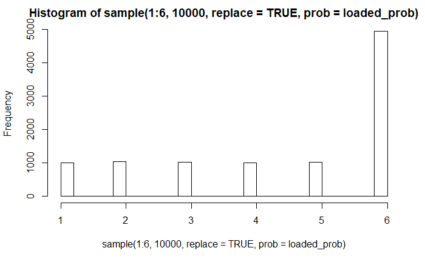

```r
hist(sample(1:6,10000,replace=TRUE,prob = loaded_prob),breaks=20)
```

- No, the loaded die histogram does not shows Uniform distribution. It can be uniform for only die sample number 1-5.
4. Modifying the code given for Fair die into loaded die so that the means vs. trial size plots are from the loaded die:

```r
#Taking the vector of trailsize whose number gives the length of the rolls.we are adding large numbers trailsize to get closer value of expected mean.
trailsizes <- c(5,10,15,20,25,30,40,50,100,200,300,400,500,1000,2000,3000,4000,5000,10000,20000,30000,100000,200000)
#storing the values of means and variance
means <- vector(mode="double",length=length(trailsizes))
variances <- vector(mode="double",length=length(trailsizes))

#for loop the length of trailsize
for (i in 1:length(trailsizes)){
  #rolls are taken from the trailsize values
  rolls <- vector(length = trailsizes[i],mode="double")
  #again loop the trailsize values
  for (j in 1:trailsizes[i]){
    rolls[j]<- sample(1:6,size=1,replace=TRUE,prob=loaded_prob) # sample for loaded die with its probabilities
  }
  #calculating mean and variance from rolls
  means[i] <- mean(rolls);
  variances[i] <- var(rolls)
}
```

- Plot for means:

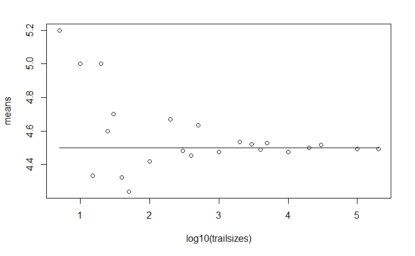

```r
#Plotting the graph for trailsize and mean of it.
plot(log10(trailsizes),means)
#This indicates the line for expected mean value on the given plot.
lines(log10(trailsizes),rep(4.50,length(trailsizes)))
```

- Plot for variances:

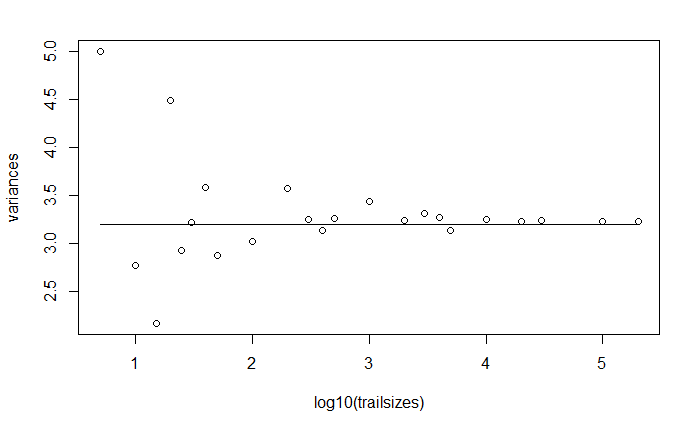

```r
#Plotting the graph for trailsize and mean of it.
plot(log10(trailsizes),variances)
#This indicates the line for expected mean value on the given plot.
lines(log10(trailsizes),rep(3.2,length(trailsizes)))
```

- When I use trailsize with large number being 200000. which is the number of rolls, the more rolls we have, closer we get to the expected values for mean and variance as 4.5 and 3.2.